# Communicating your findings effectively and reproducibly using charts produced with R and ggplot2

Since R has such infinite variety of features for charts and there is usually more than one way to accomplish a task, I find it useful to create a plot wish list for all the improvements I want to accomplish with a chart. This is also useful if you are new to R and need to look up how to make the changes.

**Plot wish list**

- Reorder chart
- Change the theme of the chart (background, axes, etc.)
- Change the color of the bars
- Highlight the United States
- Add title
- Change axes titles
- Adjust the y-axis to start at 0

By default, ggplot2 will order bars based on factors in the x axis. To get our chart to order the bars based on the number of respondents we need to tell it how to sort the data.

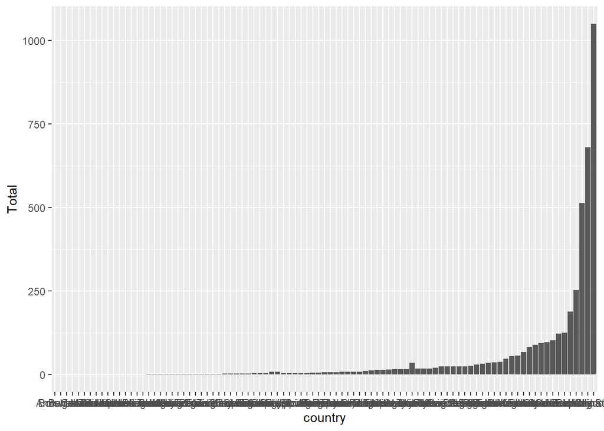

```r
homephd <- homephd %>%
  mutate(country = fct_reorder(country, Total))

#run chart again
ggplot(data = homephd, mapping=aes(x=country, y = Total)) +
  geom_col() #now ordered!
```

### Theme

The theme of your chart dictates the overall look of your chart and are preset combinations of backgrounds, axes formats, and gridline formats. A shortlist of formats is located on the second page of the ggplot2 cheatsheet. I’m a fan of the light theme so that’s what I’m going to use.

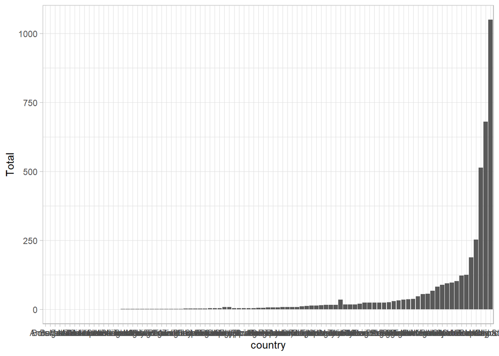

```r
ggplot(data = homephd, mapping=aes(x=country, y = Total)) +
  geom_col()+
  theme_light()
```

### Color

To change the color of our bars we are going to use the fill aesthetic within geom_col. There is also a color aesthetic and it dictates the outline of the bars.

The fill aesthetic will accept a variable name if you want the colors to be based on a category (ex. region), there is also a limited number of color names that can be used (“red”, “green”, “blue”, etc.), but if there is a specific color that you want to use, I recommend using hexidecimal color codes. My preferred site for finding hexadecimal color codes is color-hex.com but there are many other options.

There are many places to pull inspiration for chart colors:

- From an image using an image color picker
- Using copy-tested color gradients such as [ColorBrewer2](http://colorbrewer2.org/), which is built into ggplot2, or [CartoColor](http://carto.com/carto-colors/)
- Using a single color or group of colors as inspiration to create a palette using such tools as [Chroma.js Color Palette Helper](http://vis4.net/palettes/) or [Colorpicker for data](http://tristen.ca/hcl-picker/)

Points to keep in mind when choosing colors:

- Limit colors when possible
- Label directly
- Ensure strong contrast with background (involves knowing where your image will appear)
- Use color strategically to highlight or group
- Keep in mind that colors have meanings that change across cultures
- Use predefined color meanings (eg. water is blue)
- Sequential color scales should only be used on quantitative data or ordered qualitative data
- Diverging colors scales should only be used where there is a meaningful middle point

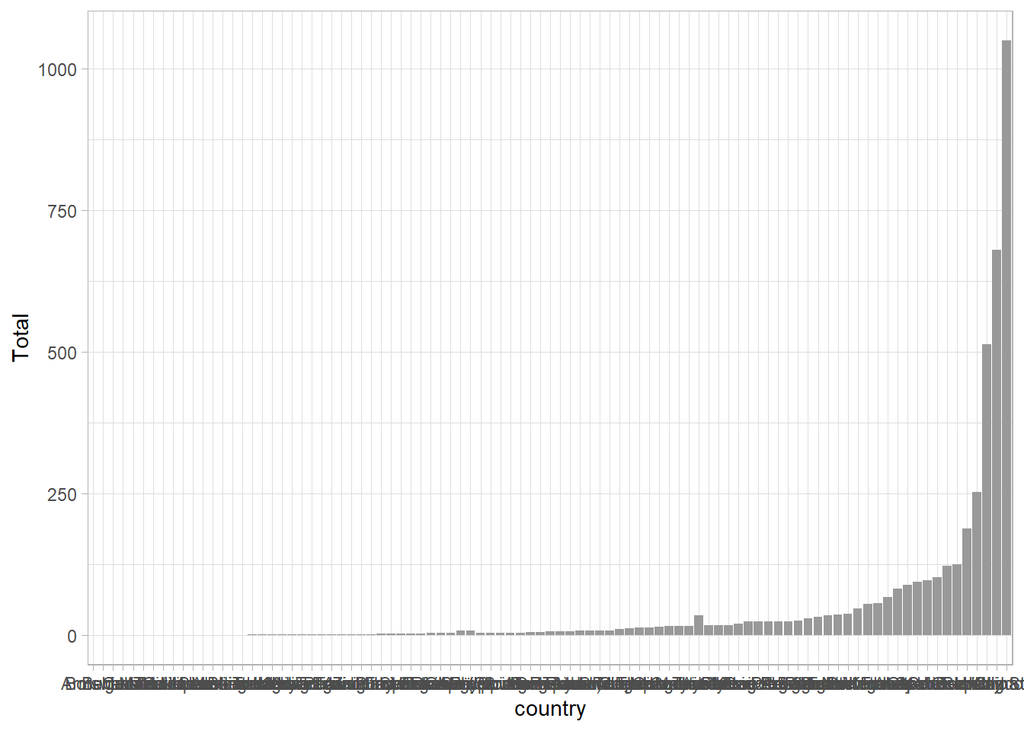

```r
ggplot(data = homephd, mapping=aes(x=country, y = Total)) +
  geom_col(fill="#999999")+
  theme_light()
```

Check out what other aesthetics are available in geom_col

```r
?geom_col
```

We can also highlight one row by adding another geom_col and filter for United States.

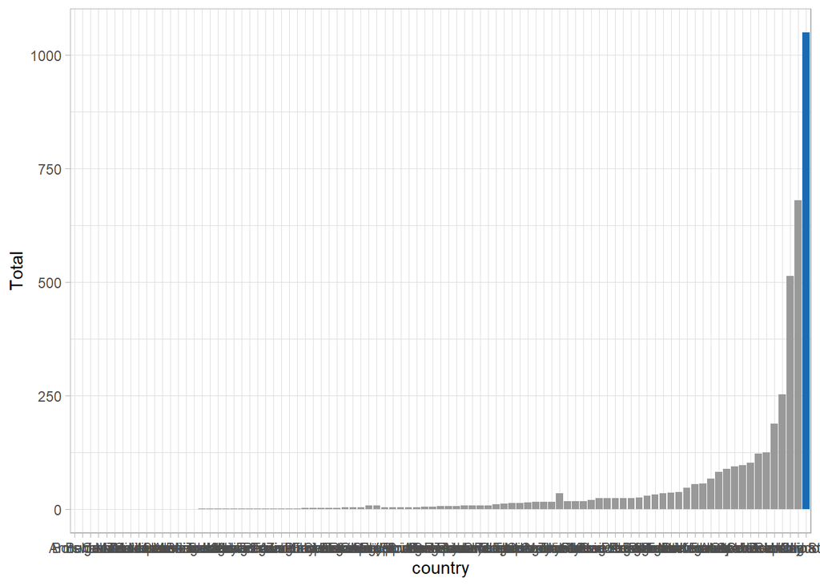

```r
ggplot(data = homephd, mapping=aes(x=country, y = Total)) +
  geom_col(fill="#999999")+
  theme_light()+
  geom_col(data = filter(homephd, country == "United States"), fill="#1b6bb4")
```

### Text

Best practices for text in charts:

- Keep text horizontal as much as possible
- Annotate figures directly to highlight key points in a chart
- Use descriptive titles

Adding title and axes using labs and formatting using theme(axis.text.x, plot.title)

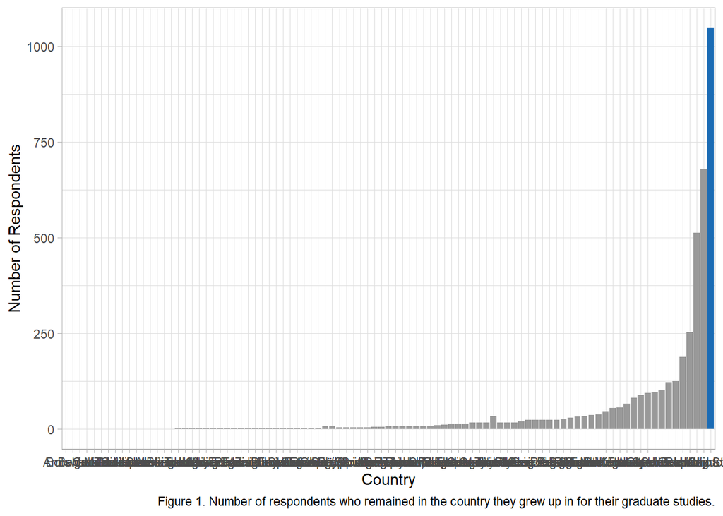

```r
ggplot(data = homephd, mapping=aes(x=country, y = Total)) +
  geom_col(fill="#999999")+
  theme_light()+
  geom_col(data = filter(homephd, country == "United States"), fill="#1b6bb4")+
  labs(x = "Country", y= "Number of Respondents", caption= "Figure 1. Number of respondents who remained in the country they grew up in for their graduate studies.")
```

All the names for the countries are overlapping at the bottom of the chart and since there are so many of them, it’ll make them easier to read if we flip the x and y axes. We accomplish this with the coord_flip() function.

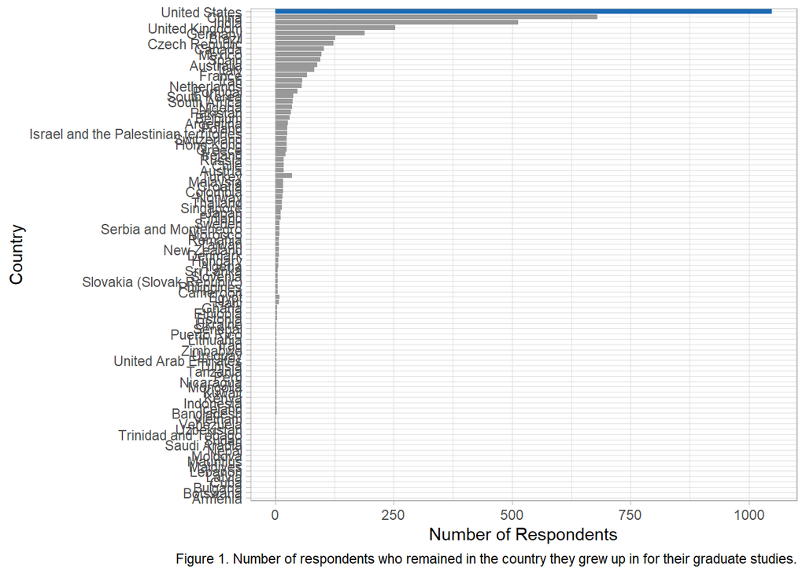

```r
ggplot(data = homephd, mapping=aes(x=country, y = Total)) +
  geom_col(fill="#999999")+
  theme_light()+
  geom_col(data = filter(homephd, country == "United States"), fill="#1b6bb4")+
  labs(x = "Country", y= "Number of Respondents", caption= "Figure 1. Number of respondents who remained in the country they grew up in for their graduate studies.")+
  coord_flip()
```

To adjust the axis so it starts at 0, we’re going to use the scale function. It also cutting off a 0 in our last label of our Number of Respondents axis so we’ll need to adjust the margin of the theme.

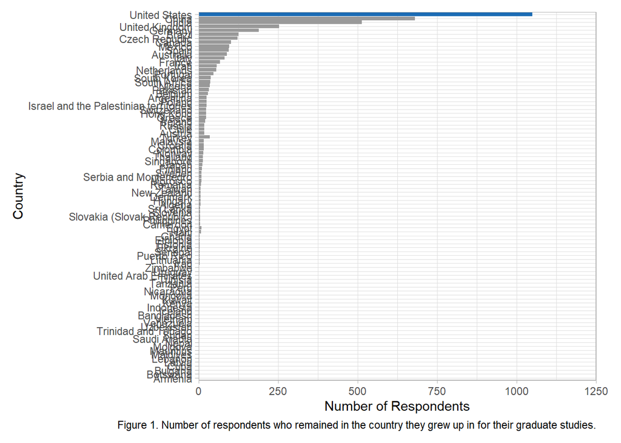

```r
ggplot(data = homephd, mapping=aes(x=country, y = Total)) +
  geom_col(fill="#999999")+
  theme_light()+
  geom_col(data = filter(homephd, country == "United States"), fill="#1b6bb4")+
  labs(x = "Country", y= "Number of Respondents", caption= "Figure 1. Number of respondents who remained in the country they grew up in for their graduate studies.")+
  scale_y_continuous(expand = c(0,0), limits= c(0, 1250))+
  coord_flip()+
  theme(plot.margin = margin(10,20,10,10))
```

You can also use the theme to style the text using element_text. Find out what you can change with element_text

```r
?element_text
```

Congratulations on completing the plot wish list!

To export our final chart and share it with the world, we’ll first assign our chart a name then use ggsave to export. With ggsave you can also specify width, height, and units.

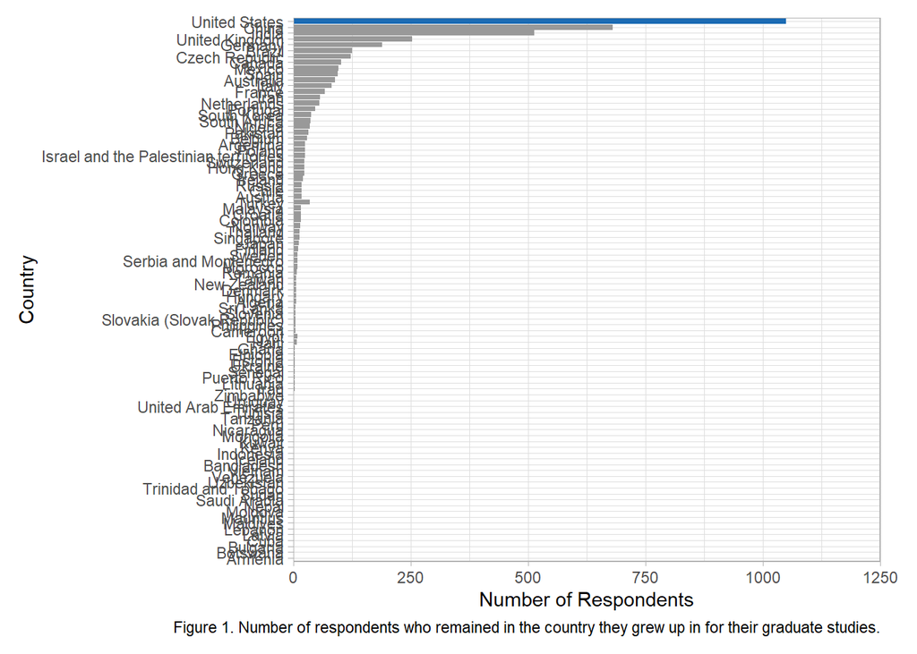

```r
homephdplot <- ggplot(data = homephd, mapping=aes(x=country, y = Total)) +
  geom_col(fill="#999999")+
  theme_light()+
  geom_col(data = filter(homephd, country == "United States"), fill="#1b6bb4")+
  labs(x = "Country", y= "Number of Respondents", caption= "Figure 1. Number of respondents who remained in the country they grew up in for their graduate studies.")+
  scale_y_continuous(expand = c(0,0), limits= c(0, 1250))+
  coord_flip()+
  theme(plot.margin = margin(10,20,10,10))

homephdplot
```

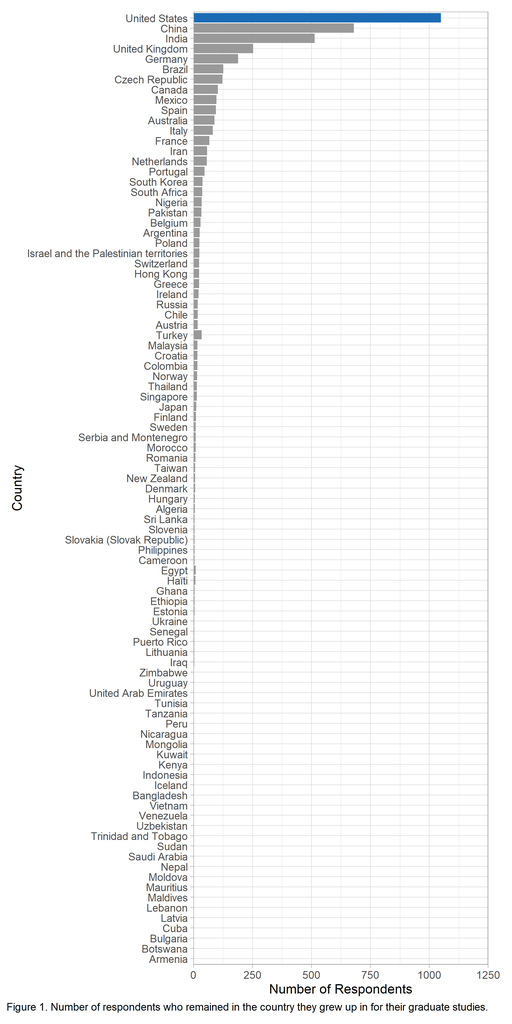

Final chart

```r
#Export chart
ggsave("./charts/HomePhDPlot.png", homephdplot, width = 6, height = 12, units = "in")
```

### Data Citation

If you are using someone else’s data, cite it!

If you published the full dataset, cite it!

- Helps readers find the original data source
- Increases the legitimacy of your chart

Copy the citation suggested where you got the data or use your preferred citation style.

Primary components:

- Author/ Creator (Individual, group, or organization)
- Title
- Year of Publication
- Publisher (often the repository where the data is housed)
- Version or edition
- Access Information (URL, DOI, or another persistent identifier)

General format:

Author (Year). Title with version. Publisher. Access information.

Citation for this dataset:

Nature. (2019). 2019 Nature PhD Students Survey Data(Version1). figshare. https://doi.org/10.6084/m9.figshare.10266299.v1

### Visualizing responsibly

Was this visualization created responsibly? What could make this visualization better?

- We didn’t distort the data (check)
- We answered our research question (check)
- Is there additional context that could be added for our audience to better understand the data? (yes)

What type of contextual data could we add? Number of respondents from each country

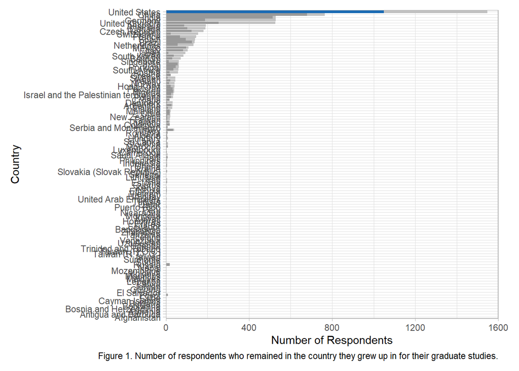

```r
#Apply the same ordering of countries from homephd to phdsurvey
phdsurvey <- phdsurvey%>%
  mutate(country = fct_reorder(country, Total))

ggplot(data = homephd, mapping=aes(x=country, y = Total)) +
  geom_col(data = phdsurvey, fill = "#c1c1c1")+ #we need to add it as a layer early in the chart since we want it to show up behind
  geom_col(fill="#999999")+
  theme_light()+
  geom_col(data = filter(homephd, country == "United States"), fill="#1b6bb4")+
  labs(x = "Country", y= "Number of Respondents", caption= "Figure 1. Number of respondents who remained in the country they grew up in for their graduate studies.")+
  scale_y_continuous(expand = c(0,0), limits= c(0, 1600))+ #need to adjust the limit to the highest number
  coord_flip()+
  theme(plot.margin = margin(10,20,10,10))
```

We could also have used ratio of respondents from that country or looked outside the dataset and found data on how many PhD students are studying in each country which would help provide a better understanding and context for the outcomes of this survey.

## Further resources for learning R

- [R for Data Science (2nd edition)](https://r4ds.hadley.nz/) by Hadley Wickham & Garrett Grolemund
- [Software Carpentry Lessons](https://software-carpentry.org/lessons/)
- [Data Carpentry Lessons](https://datacarpentry.org/lessons/)
- [Sage Research Methods R Tutorials](https://library.umassmed.edu/node/97). Search for R statistical package and filter by the video content type

## Further data visualization resources

[Lamar Soutter Library Data Visualization Resource Guide](https://libraryguides.umassmed.edu/data-viz)

Materials from a number of different sources were used in the creation of this class including:

- The Carpentries’ (previously Data Carpentry’s) R for Social Scientists used under the CC-BY 4.0 license.
- The Carpentries’ (previously Software Carpentry) Programming with R used under the CC-BY 4.0 license.
- The Carpentries’ (previously Software Carpentry) R for Reproducible Scientific Analysis used under the the CC-BY 4.0 license.
- R Course by Nick Hathaway as part of the UMMS Bootstrappers Courses
- [Visualizing the Future Data Visualization 101 module](https://visualizingthefuture.github.io/data-viz-101/)  
  This work is licensed under a [Creative Commons Attribution 4.0 International License](http://creativecommons.org/licenses/by/4.0/) by Tess Grynoch